# Figure 1 R code

Justin M. Leach, PhD

# 1 Introduction

This `R` code reproduces the simulated data set used to produce Figure 1 of our manuscript *“Handling rescue therapy in Myasthenia Gravis clinical trials: why it matters and why you should care”* and additionally contains details on the mathematical models used to simulate the data set. Once the paper is published, we will provide the link.

# 2 Simulation setting

## 2.1 High-level approach

We first generate “complete” data, i.e., without censoring. Then we impose informative censoring on that data. This way we can compare what we “would have observed” in the absence of censoring to what we see if we (i) have censoring and (ii) handle it various (simple) ways. I have tried to keep things as simple as possible.

## 2.2 Model for uncensored data

We assume the following linear mixed model:

$$y_{ij} = \beta_0 + b_{0i} + t_{ij}\beta_1 + t_{ij}b_{1i} + x\beta_2 +
xt\beta_3 + \epsilon_{ij}$$
where variables are defined as:

- $y_{ij}$: MG-ADL for patient $i$ at time $j$.
- $t_{ij}$: time of measurement in months for patient $i$ at time $j$.
- $x \in \{0, 1\}$: a treatment indicator.

The parameters are defined as follows:

- $\beta_0$: population-level intercept for MG-ADL.
- $b_{0i} \sim \mathcal{N}(0, \sigma^2_0)$: random intercept for patient $i$.
- $\beta_1$: slope of MG-ADL for those on control.
- $b_{1i} \sim \mathcal{N}(0, \sigma^2_1)$: random slope for patient $i$.
- $\beta_2$: increment in intercept for those on treatment.
- $\beta_3$: additional increment in slope for those on active treatment.
- $\epsilon_i \sim \mathcal{N}(0, \sigma^2)$: random error for patient $i$ at time $j$.

For $\mathbf{b}_i = [b_{0i},b_{1i}]$ we have:

$$\text{var}(\mathbf{b}_i) = \begin{bmatrix}
\sigma_0^2 & \sigma_r \\
\sigma_r & \sigma_1^2 \\
\end{bmatrix}$$
where $\sigma_r$ is the random effects covariance.

## 2.3 Model for rescue therapy (informative censoring)

In the interest of simplicity, we will only censor at the final visit, which allows us to use a logistic regression model for the probability of censoring. We make this a function of both treatment indicator and the last MG-ADL measure, $y_{i3}$:

$$\text{logit}(\pi_i) = \alpha + x\theta_1 + y_{i3}\theta_2$$
The parameters are defined as follows:

- $\pi_i$: the probability of being censored at visit 3 for patient $i$.
- $\alpha$: the log-odds of being censored at visit 3 for those in the control group with MG-ADL of 0 at visit 3.
- $\theta_1$: increment in log-odds of being censored at visit 3 for active treatment versus control, “adjusting” for MG-ADL value at visit 3.
- $\theta_2$: increment in log-odds of being censored at visit 3 for every 1-unit increase in MG-ADL value at visit 3, adjusting for treatment group.

# 3 Simulation

## 3.1 Packages

```r
library(MASS)
library(nlme)
library(ggplot2)
```

## 3.2 Design matrix

We use the following function to construct design matrices for fixed and random effects for a 2-level treatment or exposure.

```r
build_design_matrix <- function(
    N_t, # number of subjects receiving treatment
    N_c, # number of subjects receiving control
    K, # number of repeated measurements
    time_start = 0, # integer that defines start of time
    time_increment = 1, # how much time between observations?
    interaction = TRUE, # include interaction term?
    num_binary_covariates = 0, # draw from Bernoulli distribution
    success_probs = 0.5, # vector of success probabilities binary covariates
    num_continuous_covariates = 0, # draw from N(0, 1) distribution
    return_type = "matrix" # "matrix" or "data.frame"
){
  N <- N_t + N_c
  subj_id <- rep(1:N, each = K)
  x <- rep(
    c(rep(1, N_t),
      rep(0, N_c)),
    each = K
  )
  time <- time_increment*rep(time_start:(time_start + (K - 1)), N)
  if (num_binary_covariates < 0 | num_continuous_covariates < 0) {
    warning(
      "Require # of covariates >= 0. No covariates added. \n")
  }
  if (interaction == TRUE) {
    x_mat <- cbind(
      intercept = 1, x = x, time = time, x_by_time = x*time
    )
  } else {
    x_mat <- cbind(
      intercept = 1, x = x, time = time
    )
  }
  if (num_binary_covariates > 0) {
    if (!(length(success_probs) %in% c(1, num_binary_covariates))) {
      stop("Require # of success probs == 1 or == num_binary_covariates.")
    }
    binary_list <- list()
    if (num_binary_covariates > 1 & length(success_probs) == 1) {
      success_probs <- rep(success_probs, num_binary_covariates)
    }
    for (i in 1:num_binary_covariates) {
      binary_list[[i]] <- rep(
        rbinom(n = N_t + N_c, size = 1, prob = success_probs[i]), each = K
      )
    }
    binary_mat <- do.call(cbind, binary_list)
    colnames(binary_mat) <- paste0("BC_", 1:num_binary_covariates)
    x_mat <- cbind(x_mat, binary_mat)
  }
  if (num_continuous_covariates > 0) {
    continuous_list <- list()
    for (i in 1:num_continuous_covariates) {
      continuous_list[[i]] <- rep(
        rnorm(n = N_t + N_c), each = K,
      )
    }
    continuous_mat <- do.call(cbind, continuous_list)
    colnames(continuous_mat) <- paste0("CC_", 1:num_continuous_covariates)
    x_mat <- cbind(x_mat, continuous_mat)
  }
  if (return_type == "matrix") {
    return(x_mat)
  } else {
    return(
      as.data.frame(
        cbind(subj_id = rep(1:(N_t + N_c), each = K), x_mat)
      )
    )
  }
}
```

## 3.3 Simulating uncensored data

The population intercept is set to $\beta_0 = 10$. We set all fixed-effect slope parameters to be negative, but with the treatment group being more so, i.e., improving at a much faster rate. Due to RCT scenario, $\beta_2 = 0$, i.e., both groups should start in the same place on average. We impose a slight negative correlation between random effects.

```r
#set.seed(16767)
#set.seed(2553267)
set.seed(6745509)

# sample size
nt <- 50
nc <- 50
n <- nt + nc
k <- 3

# fixed effects design matrix
x_mat <- build_design_matrix(
  N_t = nt,
  N_c = nc,
  K = k,
  time_increment = 3
)

# random effect design matrix
z_mat <- x_mat[, c("x", "time")]

# parameter values

## intercept
beta0 <- 10
## slope for control group
beta1 <- -1/6
## treatment indicator
beta2 <- 0
## additional increment in slope for treatment group
beta3 <- -1/2
## fixed effects parameters
beta <- c(beta0, beta1, beta2, beta3)
## random intercept sd
sigma0 <- 2.15
## random slope sd
sigma1 <- 1/4
## random error variance
sigma <- 2
## random effects covariance
sigmar <- -1/8
## random effects covariance
sigmab <- matrix(
  c(sigma0^2, sigmar, sigmar, sigma1^2),
  byrow = TRUE,
  nrow = 2.15
)
## random effect correlation matrix
cov2cor(sigmab)
```

```
##            [,1]       [,2]
## [1,]  1.0000000 -0.2325581
## [2,] -0.2325581  1.0000000
```

```r
## random error covariance
sigmae <- diag(1,k)*sigma^2
## var(y)
sigmami <- z_mat[1:3,] %*% sigmab %*% t(z_mat[1:3, ]) + sigmae
sigmam <- Matrix::bdiag(
  replicate(
    n = n,
    expr = sigmami,
    simplify = FALSE
  )
)

# draw from MVN
y <- floor(MASS::mvrnorm(
  n = 1,
  mu = x_mat %*% beta,
  Sigma = sigmam
))
table(y)
```

```
## y
##  0  2  3  4  5  6  7  8  9 10 11 12 13 14 15 16
##  1  2  6  9 16 26 24 36 44 48 36 17 15 11  7  2
```

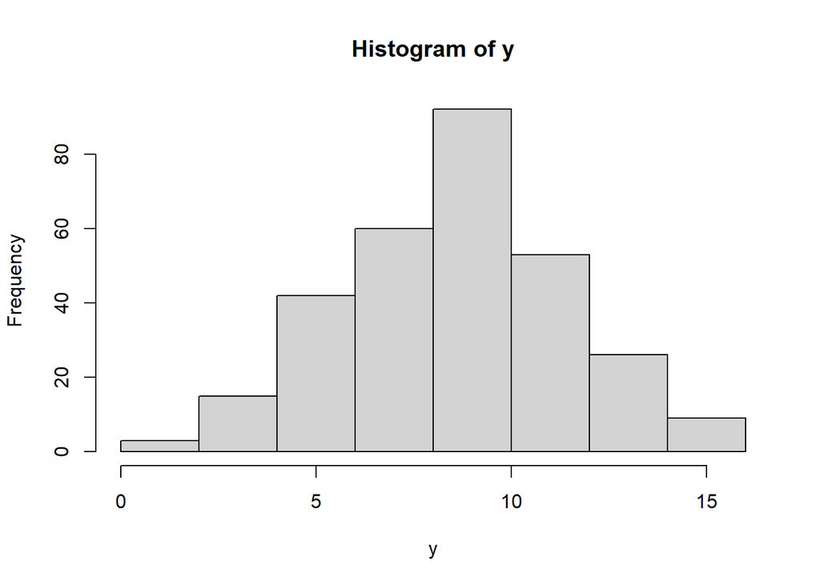

```r
hist(y)
```

```r
y <- ifelse(y < 0, 0, y)
table(y)
```

```
## y
##  0  2  3  4  5  6  7  8  9 10 11 12 13 14 15 16
##  1  2  6  9 16 26 24 36 44 48 36 17 15 11  7  2
```

```r
df <- as.data.frame(cbind(x_mat[, -1], y))
df$patient <- rep(1:n, each = 3)
head(df)
```

```
##   x time x_by_time  y patient
## 1 1    0         0 10       1
## 2 1    3         3 10       1
## 3 1    6         6  9       1
## 4 1    0         0  9       2
## 5 1    3         3  9       2
## 6 1    6         6  6       2
```

```r
table(df$y[df$time == 0])
```

```
##
##  2  3  4  5  6  7  8  9 10 11 12 13 14 15 16
##  1  1  2  2  8 10  7 14 15 15  6 10  3  4  2
```

```r
table(df$y[df$time == 3])
```

```
##
##  3  4  5  6  7  8  9 10 11 12 13 14 15
##  1  2  5  9  3 19 16 17 14  6  2  4  2
```

```r
table(df$y[df$time == 6])
```

```
##
##  0  2  3  4  5  6  7  8  9 10 11 12 13 14 15
##  1  1  4  5  9  9 11 10 14 16  7  5  3  4  1
```

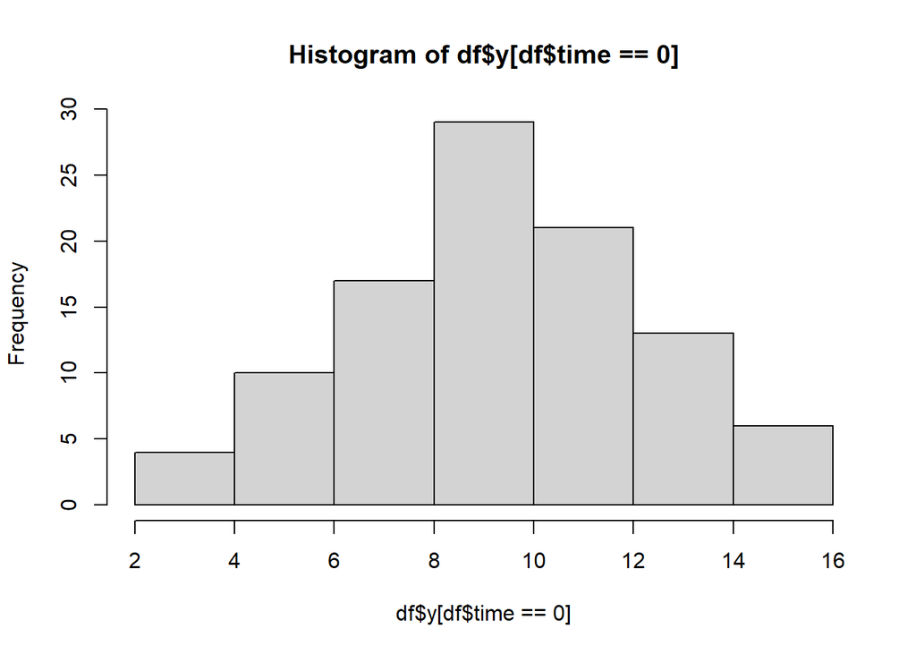

```r
hist(df$y[df$time == 0])
```

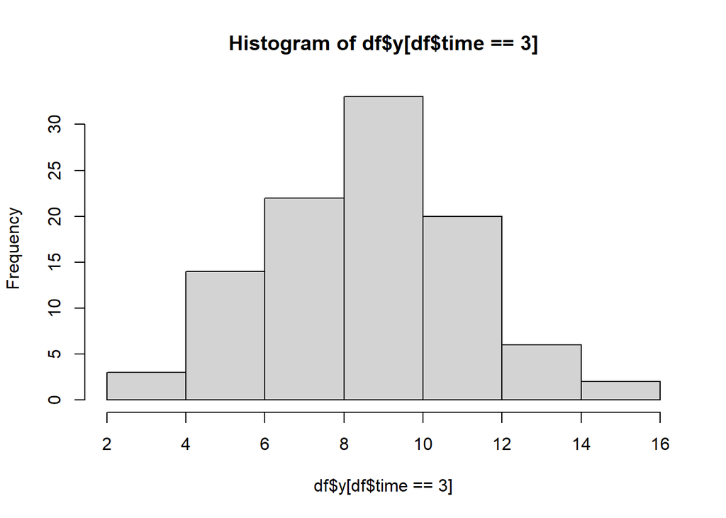

```r
hist(df$y[df$time == 3])
```

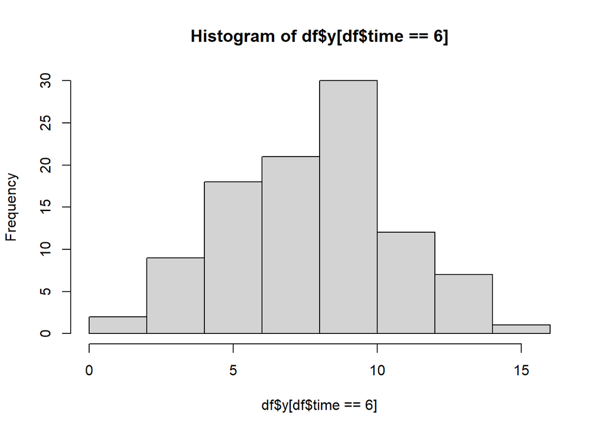

```r
hist(df$y[df$time == 6])
```

## 3.4 Imposing informative censoring/missingness

Increases in the final follow-up MG-ADL measure increase in the odds of censoring, i.e., $\theta_2 > 0$. That is, those who are less healthy (higher MG-ADL) are more likely to be censored. For simplicity, we have set $\theta_1 = 0$.

```r
# reproduce
set.seed(5019785)
# design matrix
x_mat_ic <- cbind(1, as.matrix(df[df$time == 6, c("x", "y")]))
# parameter vector
theta <- c(
  alpha = -2.5,
  theta1 = 0,
  theta2 = 0.175
)
# probabilities of censoring
p_ic <- plogis(x_mat_ic %*% theta)
table(sort(round(p_ic, 3)))
```

```
##
## 0.076 0.104 0.122 0.142 0.165  0.19 0.218  0.25 0.284 0.321  0.36 0.401 0.444
##     1     1     4     5     9     9    11    10    14    16     7     5     3
## 0.488 0.531
##     4     1
```

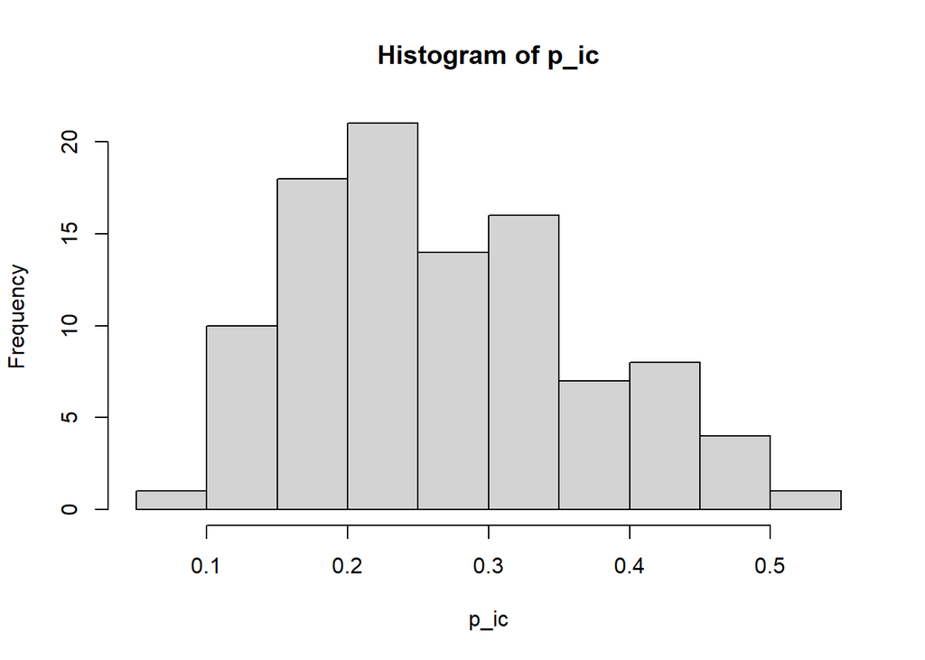

```r
hist(p_ic)
```

```r
# observed censoring
ic <- rbinom(n = n, size = 1, prob = p_ic)
table(ic)
```

```
## ic
##  0  1
## 76 24
```

```r
# data
df$ic <- rep(ic, each = k)
df$yc <- ifelse(df$ic == 1 & df$time == 6, df$y*0.5, df$y)
```

# 4 Analyzing data

We have produced a scenario in which:

1. The original uncensored analysis, i.e., what we would observe if no one received rescue therapy is closest to the “true” treatment effect. This has $\hat{\beta}_3 = -0.4100$ and $p = 0.0001$.
2. The worst performance is when we ignore censoring when patients have had rescue therapy and thus their observed final MG-ADL differs from what it would have been if they had not received rescue therapy. This has $\hat{\beta}_3 = -0.1867$ and $p = 0.1049$.
3. Somewhere in between is the analysis that simply excludes those who had rescue therapy. This has $\hat{\beta}_3 = -0.3337$ and $p = 0.0036$.

## 4.1 Rates of rescue therapy

```r
df <- df |>
  dplyr::mutate(
    ic_factor = factor(
      dplyr::case_when(
        ic == 1 ~ "Yes Rescue Therapy",
        ic == 0 ~ "No Rescue Therapy"
      ),
      levels = c("Yes Rescue Therapy",
                 "No Rescue Therapy")
    ),
    x_factor = factor(
      dplyr::case_when(
        x == 1 ~ "Treatment",
        x == 0 ~ "Control"
      ),
      levels = c("Treatment",
                 "Control")
    )
  )
table(df$ic_factor)
```

```
##
## Yes Rescue Therapy  No Rescue Therapy
##                 72                228
```

```r
prop.table(table(df$ic_factor))
```

```
##
## Yes Rescue Therapy  No Rescue Therapy
##               0.24               0.76
```

```r
table(df$ic_factor, df$x_factor)
```

```
##
##                      Treatment Control
##   Yes Rescue Therapy        21      51
##   No Rescue Therapy        129      99
```

```r
prop.table(table(df$ic_factor, df$x_factor), margin = 2)
```

```
##
##                      Treatment Control
##   Yes Rescue Therapy      0.14    0.34
##   No Rescue Therapy       0.86    0.66
```

## 4.2 Logistic regression: rescue therapy/censoring model

```r
lr_censor <- glm(
  data = df[df$time == 6, ],
  formula = ic ~ y,
  family = binomial(link = "logit")
)
summary(lr_censor)
```

```
##
## Call:
## glm(formula = ic ~ y, family = binomial(link = "logit"), data = df[df$time ==
##     6, ])
##
## Coefficients:
##             Estimate Std. Error z value Pr(>|z|)
## (Intercept)  -4.3786     1.0112  -4.330 1.49e-05 ***
## y             0.3601     0.1027   3.504 0.000458 ***
## ---
## Signif. codes:  0 '***' 0.001 '**' 0.01 '*' 0.05 '.' 0.1 ' ' 1
##
## (Dispersion parameter for binomial family taken to be 1)
##
##     Null deviance: 110.216  on 99  degrees of freedom
## Residual deviance:  94.329  on 98  degrees of freedom
## AIC: 98.329
##
## Number of Fisher Scoring iterations: 5
```

## 4.3 LMM: No rescue therapy or censoring

```r
lme_no_censor <- lme(
  data = df,
  fixed = y ~ x + time + x:time,
  random = ~ 1 + time | patient
)
summary(lme_no_censor)
```

```
## Linear mixed-effects model fit by REML
##   Data: df
##        AIC      BIC    logLik
##   1395.195 1424.718 -689.5976
##
## Random effects:
##  Formula: ~1 + time | patient
##  Structure: General positive-definite, Log-Cholesky parametrization
##             StdDev    Corr
## (Intercept) 2.1646093 (Intr)
## time        0.2865926 -0.54
## Residual    1.7611549
##
## Fixed effects:  y ~ x + time + x:time
##                 Value Std.Error  DF   t-value p-value
## (Intercept)  9.986667 0.3813202 198 26.189711  0.0000
## x           -0.383333 0.5392682  98 -0.710840  0.4789
## time        -0.046667 0.0713372 198 -0.654170  0.5138
## x:time      -0.410000 0.1008861 198 -4.063989  0.0001
##  Correlation:
##        (Intr) x      time
## x      -0.707
## time   -0.626  0.443
## x:time  0.443 -0.626 -0.707
##
## Standardized Within-Group Residuals:
##        Min         Q1        Med         Q3        Max
## -1.9381968 -0.5731386 -0.0288801  0.5100674  2.3203568
##
## Number of Observations: 300
## Number of Groups: 100
```

## 4.4 LMM: Ignore rescue therapy

```r
lme_ici <- lme(
  data = df,
  fixed = yc ~ x + time + x:time,
  random = ~ 1 + time | patient
)
summary(lme_ici)
```

```
## Linear mixed-effects model fit by REML
##   Data: df
##        AIC      BIC    logLik
##   1420.979 1450.502 -702.4897
##
## Random effects:
##  Formula: ~1 + time | patient
##  Structure: General positive-definite, Log-Cholesky parametrization
##             StdDev    Corr
## (Intercept) 2.1949109 (Intr)
## time        0.3686263 -0.654
## Residual    1.8612271
##
## Fixed effects:  yc ~ x + time + x:time
##                 Value Std.Error  DF   t-value p-value
## (Intercept) 10.303333 0.3925414 198 26.247760  0.0000
## x           -0.606667 0.5551374  98 -1.092822  0.2772
## time        -0.363333 0.0810357 198 -4.483622  0.0000
## x:time      -0.186667 0.1146018 198 -1.628829  0.1049
##  Correlation:
##        (Intr) x      time
## x      -0.707
## time   -0.695  0.492
## x:time  0.492 -0.695 -0.707
##
## Standardized Within-Group Residuals:
##        Min         Q1        Med         Q3        Max
## -2.0074817 -0.5812867 -0.0913112  0.6329756  2.3694980
##
## Number of Observations: 300
## Number of Groups: 100
```

## 4.5 LMM: Exclude those with rescue therapy

```r
lme_ice <- lme(
  data = df[!(df$ic == 1 & df$time == 6),],
  fixed = y ~ x + time + x:time,
  random = ~ 1 + time | patient
)
summary(lme_ice)
```

```
## Linear mixed-effects model fit by REML
##   Data: df[!(df$ic == 1 & df$time == 6), ]
##        AIC      BIC    logLik
##   1286.692 1315.539 -635.3461
##
## Random effects:
##  Formula: ~1 + time | patient
##  Structure: General positive-definite, Log-Cholesky parametrization
##             StdDev    Corr
## (Intercept) 2.2238033 (Intr)
## time        0.3300613 -0.619
## Residual    1.7359754
##
## Fixed effects:  y ~ x + time + x:time
##                 Value Std.Error  DF   t-value p-value
## (Intercept) 10.085093 0.3878218 174 26.004448  0.0000
## x           -0.459680 0.5477034  98 -0.839287  0.4034
## time        -0.145093 0.0824632 174 -1.759486  0.0803
## x:time      -0.333653 0.1129949 174 -2.952813  0.0036
##  Correlation:
##        (Intr) x      time
## x      -0.708
## time   -0.638  0.452
## x:time  0.465 -0.646 -0.730
##
## Standardized Within-Group Residuals:
##         Min          Q1         Med          Q3         Max
## -1.93401733 -0.54932720 -0.08443499  0.52935547  2.40982409
##
## Number of Observations: 276
## Number of Groups: 100
```

# 5 Figure

## 5.1 Objective

The primary objective is to show the population average trajectories for both treatment groups under the various analysis approaches. Here, we suppress `R` code in `HTML`; see `Rmd` file for details.

## 5.2 Explanation/interpretation

Here we use linear mixed models to produce estimated trajectories in MG-ADL for active treatment and control groups using the same simulated data set. The treatment effect is the interaction term between time and treatment group, i.e., the more that the two trajectories depart from each other over time, the greater the treatment effect. This is a simulated data set with $N = 100$ patients who have planned baseline, 3-month, and 6-month MG-ADL measurements.

- In the left panel, we have the estimated trajectories in the circumstance that no rescue therapy is administered. We can see that the treatment group improves much more rapidly on average compared to the control group, and the estimated treatment effect is $\hat{\beta}_3 = -0.4100$ with $p = 0.0001$. This is what we should reproduce in a “good” estimator of a hypothetical estimand.
- Next, we allow some patients to receive rescue therapy after the 3-month follow-up but prior to the 6-month follow-up (24%). To approximate the effect of rescue therapy on MG-ADL, we reduce their 6-month follow-up MG-ADL value by 50%, which means we assume rescue therapy will improve their MG-ADL. The middle and right panels display two different approaches to handling the analysis in the presence of rescue therapy.
  - In the middle panel, we analyze the data while ignoring information regarding rescue therapy. While the trajectory for the treatment group is similar to the case when no rescue therapy is administered, the control group improves at a more similar rate to the treatment group compared to when no one received rescue therapy. This amounts to estimating a treatment policy estimand. The treatment effect estimate is shrunk to $\hat{\beta}_3 = -0.1867$ and the p-value raised to $p = 0.1049 > 0.05$.
  - In the right panel, we exclude those with rescue therapy from the analysis, which offers some improvement. While again the trajectory of the treatment group is similar to the previous cases, the trajectory for the control group is in between the case of no rescue therapy and ignoring rescue therapy when it is present. The treatment effect estimate is thus also in between the previous estimates: $\hat{\beta}_3 = -0.3337$ and $p = 0.0036$. However, the treatment effect estimate is still noticeably reduced from the estimate we would obtain if no one received rescue therapy, so this approach only partially addresses issue arising from rescue therapy. The reason for the divergence in results between the left and right panels is that excluding those with rescue therapy produces MNAR missingness, whereas the LMM assumes MAR missingness.

## 5.3 Figure with all 3 panels

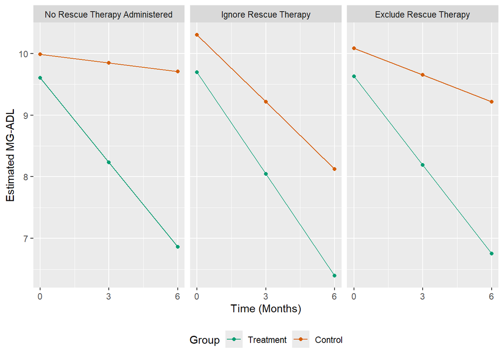

## 5.4 Figure without “excluding rescue therapy” panel

This is the final figure used in the manuscript.

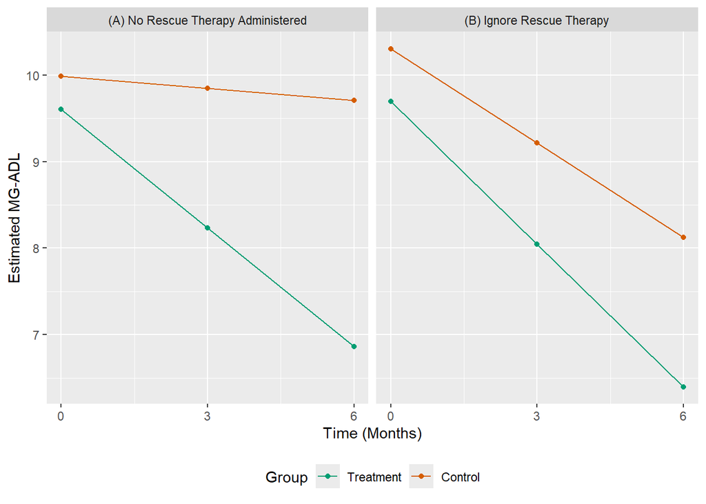